# hw08

K Iwasaki

June 30, 2017

### a. Examine the skipped variable and argue whether or not a t-test is valid for this scenario

As shown in the chart below, the skipped variable is skewed to the right. Thus, t-test is not valid for this scenario

```r
load("GPA1.RData")
head(data)
```

```
##   age soph junior senior senior5 male campus business engineer colGPA
## 1  21    0      0      1       0    0      0        1        0    3.0
## 2  21    0      0      1       0    0      0        1        0    3.4
## 3  20    0      1      0       0    0      0        1        0    3.0
## 4  19    1      0      0       0    1      1        1        0    3.5
## 5  20    0      1      0       0    0      0        1        0    3.6
## 6  20    0      0      1       0    1      1        1        0    3.0
##   hsGPA ACT job19 job20 drive bike walk voluntr PC greek car siblings
## 1   3.0  21     0     1     1    0    0       0  0     0   1        1
## 2   3.2  24     0     1     1    0    0       0  0     0   1        0
## 3   3.6  26     1     0     0    0    1       0  0     0   1        1
## 4   3.5  27     1     0     0    0    1       0  0     0   0        1
## 5   3.9  28     0     1     0    1    0       0  0     0   1        1
## 6   3.4  25     0     0     0    0    1       0  0     0   1        1
##   bgfriend clubs skipped alcohol gradMI fathcoll mothcoll
## 1        0     0       2     1.0      1        0        0
## 2        1     1       0     1.0      1        1        1
## 3        0     1       0     1.0      1        1        1
## 4        0     0       0     0.0      0        0        0
## 5        1     0       0     1.5      1        1        0
## 6        0     0       0     0.0      0        1        0
```

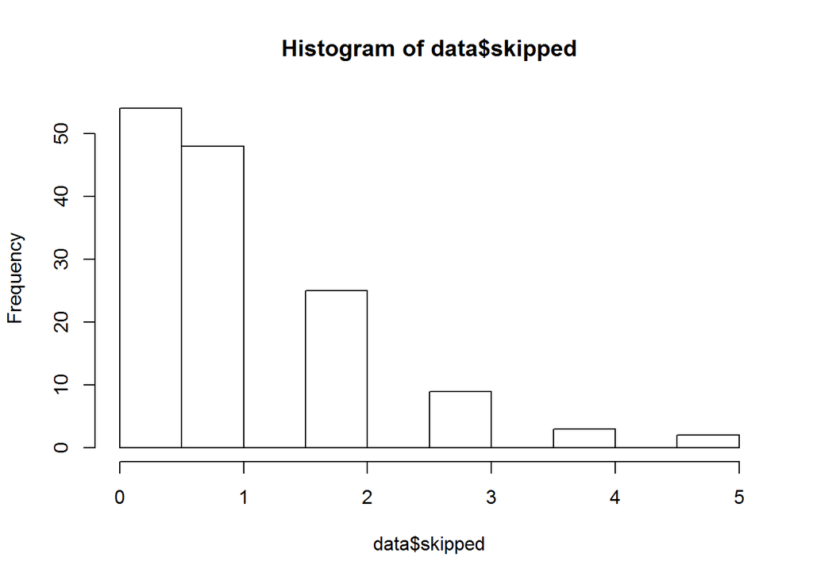

```r
hist(data$skipped)
```

```r
table(data$skipped)
```

```
##
##    0 0.25  0.5    1    2    3    4    5
##   44    1    9   48   25    9    3    2
```

### b. How would your answer to part a change if Mr. Lemmon selected dormitory rooms at random, then interviewed all occupants in the rooms he selected?

As long as Mr. Lemmon selects sufficiently large samples (n > 30), t-test is valid for this scenario

### c. Provide an argument for why you should choose a 2-tailed test in this instance, even if you are hoping to demonstrate that MSU students skip more than 1 lecture per week.

Because we don’t know whether the MSU students skip more or less than 1 lecture per week on the average, we should carry out a 2-tailed test in this instance in order to make the test more conservative.

## d. Conduct the t-test using the t.test function and interpret every component of the results.

```r
t.test(data$skipped, alternative = "two.sided", mu = 1, conf.level = 0.95)
```

```
##
##  One Sample t-test
##
## data:  data$skipped
## t = 0.83142, df = 140, p-value = 0.4072
## alternative hypothesis: true mean is not equal to 1
## 95 percent confidence interval:
##  0.8949445 1.2575377
## sample estimates:
## mean of x
##  1.076241
```

### e. Show how you would compute the t-statistic and p-value manually (without using t.test), using the pt function in R.

```r
# calculate statistics
s.mean <- mean(data$skipped)
s.stdev <- sd(data$skipped)
n <- length(data$skipped)

# critical value
a <- 1 - 0.95
(c.value <- abs(qt(p = a/2, df = n-1)))
```

```
## [1] 1.977054
```

```r
# t-stat
(t <- (s.mean - 1) / (s.stdev / sqrt(n) ))
```

```
## [1] 0.8314156
```

```r
# p-value
2 * pt(q= -t, df = n-1)
```

```
## [1] 0.4071547
```

```r
# standard error
(s.error <- s.stdev / sqrt(n))
```

```
## [1] 0.09170039
```

```r
# 95% confidence interval
c(s.mean - c.value * s.error, s.mean + c.value * s.error)
```

```
## [1] 0.8949445 1.2575377
```

### f. Construct a 99% confidence interval for the mean number classes skipped by MSU students in a week.

```r
# critical value 99%
a <- 1 - 0.99
(c.value <- abs(qt(p = a/2, df = n-1)))
```

```
## [1] 2.611403
```

```r
# standard error
(s.error <- s.stdev / sqrt(n))
```

```
## [1] 0.09170039
```

```r
# 99% confidence interval
c(s.mean - c.value * s.error, s.mean + c.value * s.error)
```

```
## [1] 0.8367745 1.3157078
```

### g. Can you say that there is a 99% chance the population mean falls inside your confidence interval?

No. Confidence is on methodology. 99% confidence interval means that if we use the same methodology to construct 99% confidence intervals. 99% of the intervals capture the population mean.